# team.Rmd

```r
  lvlCountry <- factor(choco$Location, levels = unique(choco$Location))
  table(lvlCountry)
```

```
## lvlCountry
##                U.S.A.                France                  Fiji
##                   966                   175                     4
##               Vanuatu               Ecuador                Mexico
##                     4                    57                     8
##           Switzerland           Netherlands                 Spain
##                    43                     8                    36
##                Russia                  Peru                Canada
##                     3                    22                   161
##                 Italy                Brazil             Nicaragua
##                    73                    24                    10
##                  U.K.             Australia           Philippines
##                   126                    53                     5
##                 Wales               Belgium               Vietnam
##                     1                    59                    15
##               Germany             Singapore             Venezuela
##                    42                    13                    31
##              Malaysia           South Korea                Taiwan
##                     3                    11                    10
##           Puerto Rico              Colombia                 Japan
##                     4                    25                    31
##           New Zealand            Costa Rica               Hungary
##                    27                     9                    25
##             Amsterdam              Scotland            Martinique
##                    12                    10                     1
##              Sao Tome             St. Lucia             Argentina
##                     4                     3                     9
##             Guatemala          South Africa    Dominican Republic
##                    10                     4                    11
##   Sao Tome & Principe               Bolivia              Portugal
##                     4                     2                     3
##                Norway               Denmark               Grenada
##                     3                    31                     3
##                Israel                 India St.Vincent-Grenadines
##                     9                     2                     1
##        Czech Republic              Thailand               Finland
##                     3                     5                     2
##            Madagascar                Sweden                Poland
##                    17                     6                     8
##               Austria              Honduras                U.A.E.
##                    30                     6                     5
##             Lithuania               Ireland                 Chile
##                     8                     5                     2
##                 Ghana               Iceland              Suriname
##                     1                     4                     1
##           El Salvador
##                     3
```

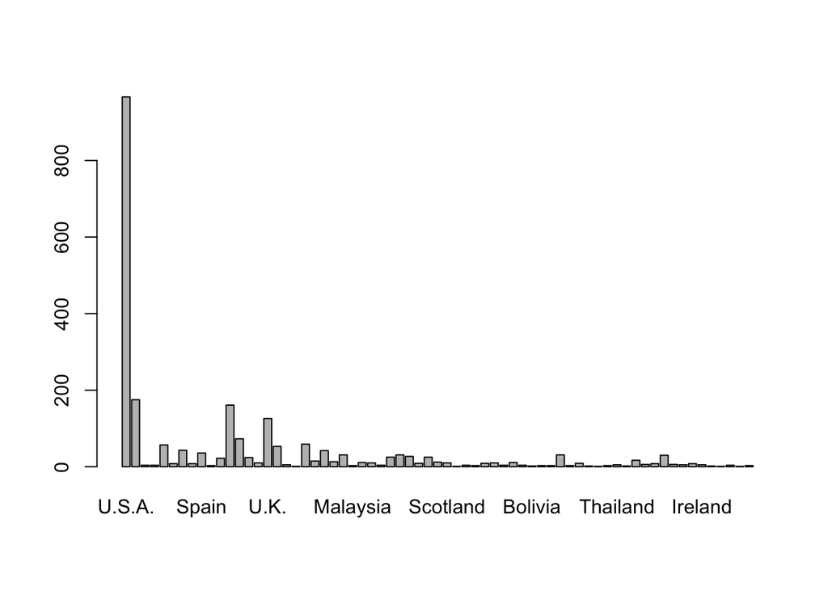

```r
  barplot(table(lvlCountry))
```

Companies in locations that have wealth and the market for chocolate will have more reviews. An example would be the United States, as we have the wealth to purchase the chocolate and the market to sell it.

3.Do ratings depend on the cacao percentage of a chocolate bar? Create both numerical and graphical summaries, and explain. [Hint: Think about why the scatterplot is not a very good choice for visualization here.]

Answer:

```r
cor(choco$Cocoa_Percent, choco$Rating)
```

```
## [1] -0.1510178
```

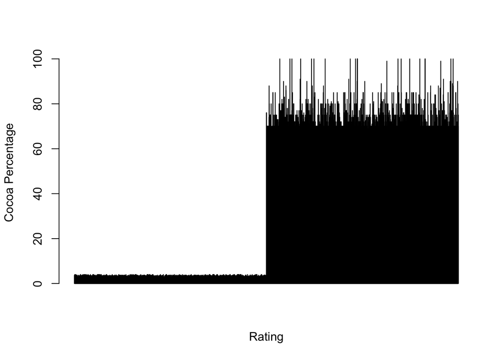

```r
w<- choco$Rating
z<- choco$Cocoa_Percent
g<- c(w,z)
barplot(g,xlab='Rating', ylab='Cocoa Percentage')
```

The correlation coefficient is very low and combined with the bar graph it is clear that ratings are not dependent on cocoa percentage.

4.How do different bean origins compare in terms of the flavor of chocolates? Are beans from some places better than the other? Create both numerical and graphical summaries, and explain.

Answer:

```r
  choco <- read.csv("https://raw.githubusercontent.com/xdaiISU/ds202materials/master/hwlabs/data/choco.csv")
  str(choco)
```

```
## 'data.frame':    2312 obs. of  13 variables:
##  $ REF                 : int  2454 2458 2454 797 797 1015 1019 1011 1019 1011 ...
##  $ Company             : chr  "5150" "5150" "5150" "A. Morin" ...
##  $ Location            : chr  "U.S.A." "U.S.A." "U.S.A." "France" ...
##  $ Date                : int  2019 2019 2019 2012 2012 2013 2013 2013 2013 2013 ...
##  $ Bean_Origin         : chr  "Madagascar" "Dominican Republic" "Tanzania" "Peru" ...
##  $ Specific_Bean_Origin: chr  "Bejofo Estate, batch 1" "Zorzal, batch 1" "Kokoa Kamili, batch 1" "Peru" ...
##  $ Cocoa_Percent       : num  76 76 76 63 70 70 63 70 70 70 ...
##  $ Ingredients         : chr  "3- B,S,C" "3- B,S,C" "3- B,S,C" "4- B,S,C,L" ...
##  $ Characteristics1    : chr  "cocoa" "cocoa" "rich cocoa" "fruity" ...
##  $ Characteristics2    : chr  "blackberry" "vegetal" "fatty" "melon" ...
##  $ Characteristics3    : chr  "full body" "savory" "bready" "roasty" ...
##  $ Characteristics4    : chr  NA NA NA NA ...
##  $ Rating              : num  3.75 3.5 3.25 3.75 3.5 4 4 3.75 3.5 3.25 ...
```

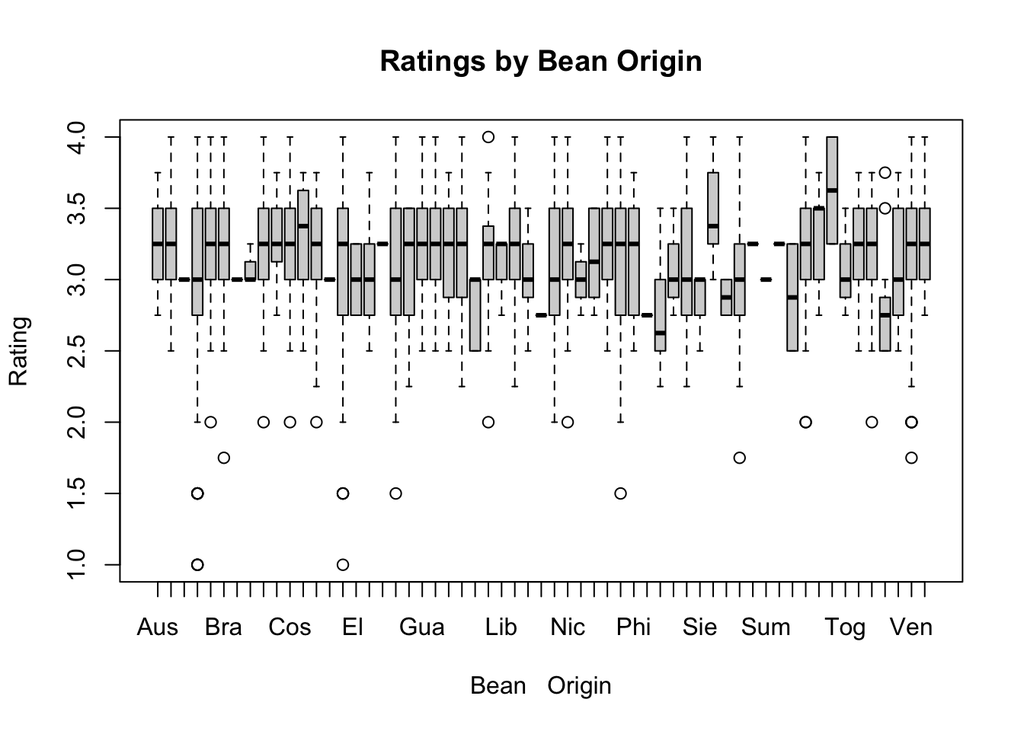

```r
  BOfct <- factor(choco$Bean_Origin)
  levels(BOfct) <- substr(levels(BOfct), 1, 3)
  boxplot(choco$Rating ~ BOfct, main = "Ratings by Bean Origin", xlab = "Bean   Origin", ylab = "Rating")
```

```r
outstanding<- choco[choco$Rating >= 3.5,]
q<- outstanding['Bean_Origin']
as.data.frame(table(q))
```

```
##                      q Freq
## 1            Australia    1
## 2               Belize   22
## 3                Blend   52
## 4              Bolivia   23
## 5               Brazil   33
## 6             Colombia   22
## 7                Congo    5
## 8           Costa Rica   13
## 9                 Cuba    6
## 10  Dominican Republic   75
## 11             Ecuador   88
## 12                Fiji    3
## 13               Ghana   15
## 14             Grenada    6
```

[output cut: 30 more lines]

From the boxplot we can see that the countries of origin that sit above the rest have observations with ratings higher than 3.5 so we searched for all the countries that had observations above 3.5. The countries that sit above the rest should have higher frequencies of observations higher than 3.5 so we made a table displaying these frequencies. From this table we can see that Ecuador, Peru and Venezuela have the highest amounts of observations where the rating is greater than or equal to 3.5. Their frequencies are significantly higher than the rest (88, 85, 104 respectively).

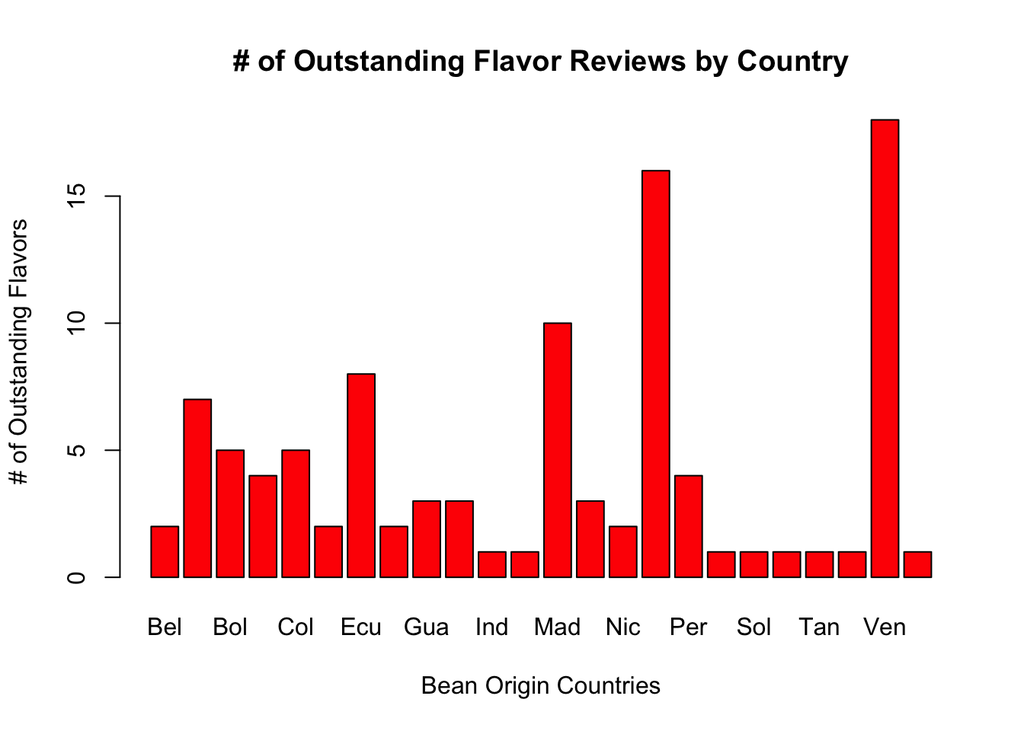

```r
chocoHRO <- choco[choco$Rating >= 4.0,]
belize <- chocoHRO[chocoHRO$Bean_Origin == "Belize", ]
blend <- chocoHRO[chocoHRO$Bean_Origin == "Blend", ]
bolivia <- chocoHRO[chocoHRO$Bean_Origin == "Bolivia", ]
brazil <- chocoHRO[chocoHRO$Bean_Origin == "Brazil", ]
colombia <- chocoHRO[chocoHRO$Bean_Origin == "Colombia", ]
costaRica <- chocoHRO[chocoHRO$Bean_Origin == "Costa Rica", ]
ecuador <- chocoHRO[chocoHRO$Bean_Origin == "Ecuador", ]
ghana <- chocoHRO[chocoHRO$Bean_Origin == "Ghana", ]
guatemala <- chocoHRO[chocoHRO$Bean_Origin == "Guatemala", ]
haiti <- chocoHRO[chocoHRO$Bean_Origin == "Haiti", ]
indonesia <- chocoHRO[chocoHRO$Bean_Origin == "Indonesia", ]
jamaica <- chocoHRO[chocoHRO$Bean_Origin == "Jamaica", ]
madagascar <- chocoHRO[chocoHRO$Bean_Origin == "Madagascar", ]
mexico <- chocoHRO[chocoHRO$Bean_Origin == "Mexico", ]
nicaragua <- chocoHRO[chocoHRO$Bean_Origin == "Nicaragua", ]
pnewguinea <- chocoHRO[chocoHRO$Bean_Origin == "Papua New Guinea", ]
peru <- chocoHRO[chocoHRO$Bean_Origin == "Peru", ]
saotome <- chocoHRO[chocoHRO$Bean_Origin == "Sao Tome", ]
solomonislands <- chocoHRO[chocoHRO$Bean_Origin == "Solomon Islands", ]
stlucia <- chocoHRO[chocoHRO$Bean_Origin == "St. Lucia", ]
tanzania <- chocoHRO[chocoHRO$Bean_Origin == "Tanzania", ]
tobago <- chocoHRO[chocoHRO$Bean_Origin == "Tobago", ]
venezuela <- chocoHRO[chocoHRO$Bean_Origin == "Venezuela", ]
vietnam <- chocoHRO[chocoHRO$Bean_Origin == "Vietnam", ]


belizeCount <- length(belize$Rating)
blendCount <- length(blend$Rating)
boliviaCount <- length(bolivia$Rating)
brazilCount <- length(brazil$Rating)
colombiaCount <- length(colombia$Rating)
costaRicaCount <- length(costaRica$Rating)
ecuadorCount <- length(ecuador$Rating)
ghanaCount <- length(ghana$Rating)
guatemalaCount <- length(guatemala$Rating)
haitiCount <- length(haiti$Rating)
indonesiaCount <- length(indonesia$Rating)
jamaicaCount <- length(jamaica$Rating)
madagascarCount <- length(madagascar$Rating)
mexicoCount <- length(mexico$Rating)
nicaraguaCount <- length(nicaragua$Rating)
pnewguineaCount <- length(pnewguinea$Rating)
peruCount <- length(peru$Rating)
saotomeCount <- length(saotome$Rating)
solomonislandsCount <- length(solomonislands$Rating)
stluciaCount <- length(stlucia$Rating)
tanzaniaCount <- length(tanzania$Rating)
tobagoCount <- length(tobago$Rating)
venezuelaCount <- length(venezuela$Rating)
vietnamCount <- length(vietnam$Rating)

counts <- c(belizeCount, blendCount, boliviaCount, brazilCount, colombiaCount, costaRicaCount, ecuadorCount, ghanaCount, guatemalaCount, haitiCount, indonesiaCount, jamaicaCount, madagascarCount, mexicoCount, nicaraguaCount, peruCount, pnewguineaCount, saotomeCount, solomonislandsCount, stluciaCount, tanzaniaCount, tobagoCount, venezuelaCount, vietnamCount)
countryNames <- sort(unique(chocoHRO$Bean_Origin))

?barplot
barplot(counts, names.arg = substr(countryNames, 1, 3), main = "# of Outstanding Flavor Reviews by Country", xlab = "Bean Origin Countries", ylab = "# of Outstanding Flavors", col = "red")
```

5.Brainstorm two analyses you would like to perform (with your teammates). Describe in plain language what comparisons are you making. Create suitable numerical and graphical summaries for your analyses. Describe the results.

Answer:

```r
choco <- read.csv("https://raw.githubusercontent.com/xdaiISU/ds202materials/master/hwlabs/data/choco.csv")
str(choco)
```

```
## 'data.frame':  2312 obs. of  13 variables:
##  $ REF                 : int  2454 2458 2454 797 797 1015 1019 1011 1019 1011 ...
##  $ Company             : chr  "5150" "5150" "5150" "A. Morin" ...
##  $ Location            : chr  "U.S.A." "U.S.A." "U.S.A." "France" ...
##  $ Date                : int  2019 2019 2019 2012 2012 2013 2013 2013 2013 2013 ...
##  $ Bean_Origin         : chr  "Madagascar" "Dominican Republic" "Tanzania" "Peru" ...
##  $ Specific_Bean_Origin: chr  "Bejofo Estate, batch 1" "Zorzal, batch 1" "Kokoa Kamili, batch 1" "Peru" ...
##  $ Cocoa_Percent       : num  76 76 76 63 70 70 63 70 70 70 ...
##  $ Ingredients         : chr  "3- B,S,C" "3- B,S,C" "3- B,S,C" "4- B,S,C,L" ...
##  $ Characteristics1    : chr  "cocoa" "cocoa" "rich cocoa" "fruity" ...
##  $ Characteristics2    : chr  "blackberry" "vegetal" "fatty" "melon" ...
##  $ Characteristics3    : chr  "full body" "savory" "bready" "roasty" ...
##  $ Characteristics4    : chr  NA NA NA NA ...
##  $ Rating              : num  3.75 3.5 3.25 3.75 3.5 4 4 3.75 3.5 3.25 ...
```

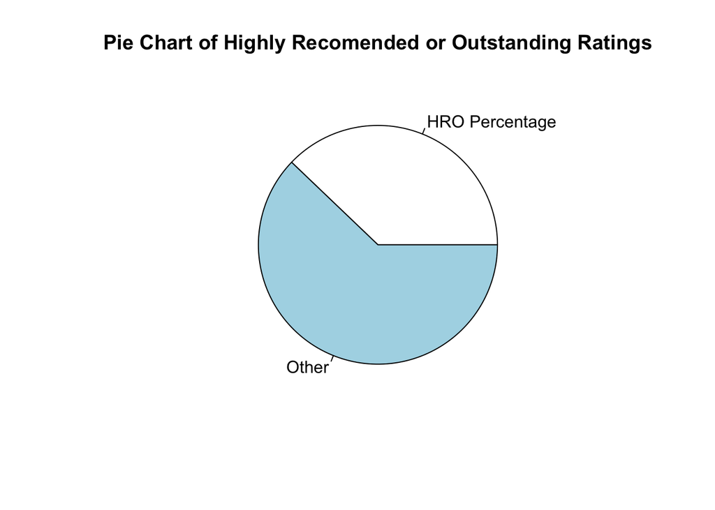

```r
totalRatings <- length(choco$Rating)
ratingsHRO <- choco[choco$Rating >= 3.5,]
HROCount <- length(ratingsHRO$Rating)
HROPercentage <- HROCount / totalRatings
nonHROPercentage <- 1.0 - HROPercentage

slices <- c(HROPercentage, nonHROPercentage)
lbls <- c("HRO Percentage", "Other")


pie(slices, labels = lbls, main = "Pie Chart of Highly Recomended or Outstanding Ratings")
```

The analysis and pie chart above show the percentage of Highly Recommended or Outstanding flavor ratings compared to the other ratings. Around 38% of the reviews are either “Highly Recommended” or “Outstanding”. This appears to be a little high, as the boxplot in Question 4 shows many of the averages of the reviews being in the “Recommended” Category.

```r
choco <- read.csv("https://raw.githubusercontent.com/xdaiISU/ds202materials/master/hwlabs/data/choco.csv")
str(choco)
```

```
## 'data.frame':    2312 obs. of  13 variables:
##  $ REF                 : int  2454 2458 2454 797 797 1015 1019 1011 1019 1011 ...
##  $ Company             : chr  "5150" "5150" "5150" "A. Morin" ...
##  $ Location            : chr  "U.S.A." "U.S.A." "U.S.A." "France" ...
##  $ Date                : int  2019 2019 2019 2012 2012 2013 2013 2013 2013 2013 ...
##  $ Bean_Origin         : chr  "Madagascar" "Dominican Republic" "Tanzania" "Peru" ...
##  $ Specific_Bean_Origin: chr  "Bejofo Estate, batch 1" "Zorzal, batch 1" "Kokoa Kamili, batch 1" "Peru" ...
##  $ Cocoa_Percent       : num  76 76 76 63 70 70 63 70 70 70 ...
##  $ Ingredients         : chr  "3- B,S,C" "3- B,S,C" "3- B,S,C" "4- B,S,C,L" ...
##  $ Characteristics1    : chr  "cocoa" "cocoa" "rich cocoa" "fruity" ...
##  $ Characteristics2    : chr  "blackberry" "vegetal" "fatty" "melon" ...
##  $ Characteristics3    : chr  "full body" "savory" "bready" "roasty" ...
##  $ Characteristics4    : chr  NA NA NA NA ...
##  $ Rating              : num  3.75 3.5 3.25 3.75 3.5 4 4 3.75 3.5 3.25 ...
```

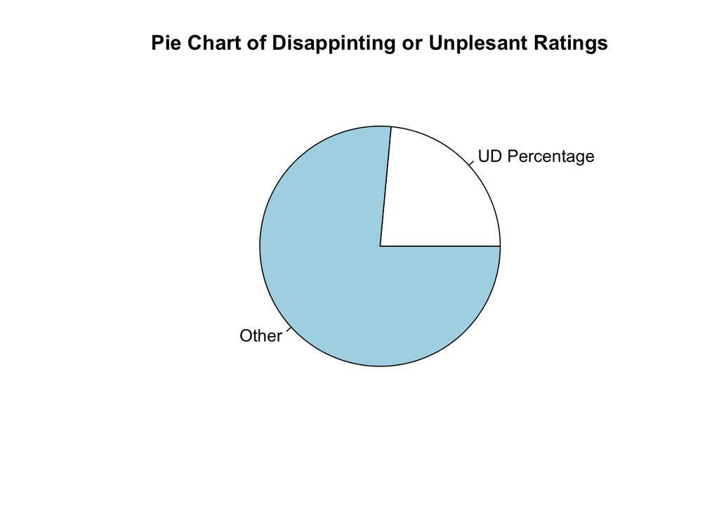

```r
totalRatings <- length(choco$Rating)
ratingsUD <- choco[choco$Rating <= 2.9,]
HROCount <- length(ratingsUD$Rating)
UDPercentage <- HROCount / totalRatings
nonUDPercentage <- 1.0 - UDPercentage

slices2 <- c(UDPercentage, nonUDPercentage)
lbls2 <- c("UD Percentage", "Other")


pie(slices2, labels = lbls2, main = "Pie Chart of Disappinting or Unplesant Ratings")
```

The second analysis was to look at how many reviews received a “Disappointing” or “Unpleasant” flavor review compared to the rest of the reviews. From our analysis, we noted that around 24% of the reviews received a review in the two categories. This makes more sense as to why the reviews averaged in the “Recommended” category, since most of the Highly “Recommended” or “Outstanding” reviews were leveled out with “Disappointing” or “Unpleasant” reviews.